# Biking numbers in Madison: Not so great

Harald Kliems

9/23/2020

Once a year in September, the US Census Bureau publishes the latest annual data from the [American Community Survey (ACS)](https://www.census.gov/programs-surveys/acs/). Included is information about how people commute to work. Transportation planners and advocates often rely on this data. Not so much because it is the absolutely best data, but because we don’t have a whole lot of other data about biking. This post will take deep dive into the commuting data for Madison over the past couple years.

Let’s start with bike commuting: What’s the proportion of people biking to work[^1] in the City of Madison, and how has it changed over time?

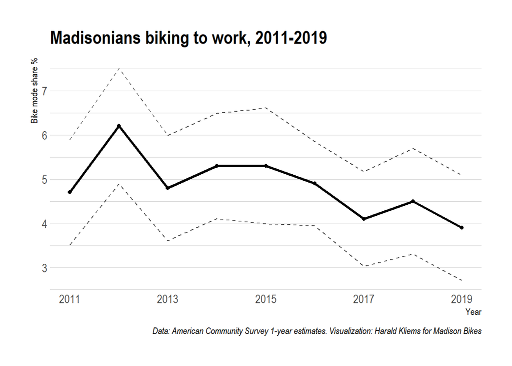

We can see what looks like a slow downward trend, from around 5% in 2011 to 2016, to around 4% in the last few years. Note the dashed lines, though: These are the margins of error. Because the American Community Survey only send its survey to a sample of people (unlike the currently [ongoing 2020 Census](https://2020census.gov/en.html), which counts everyone), there is some of uncertainty in its numbers. What that means is that in 2019 the true number of people commuting could be as low as 2.7% or as high as 5.1%. And based on the data, it’s possible that in 2012 – the year with the apparent upward spike – *fewer* people were commuting than in 2019. Again, this is among the best data we have available, but keep this uncertainty in mind when reading the rest of this post. And even in light of this uncertainty it is pretty safe to say: Bike commuting in Madison hasn’t grown over the past nine years.

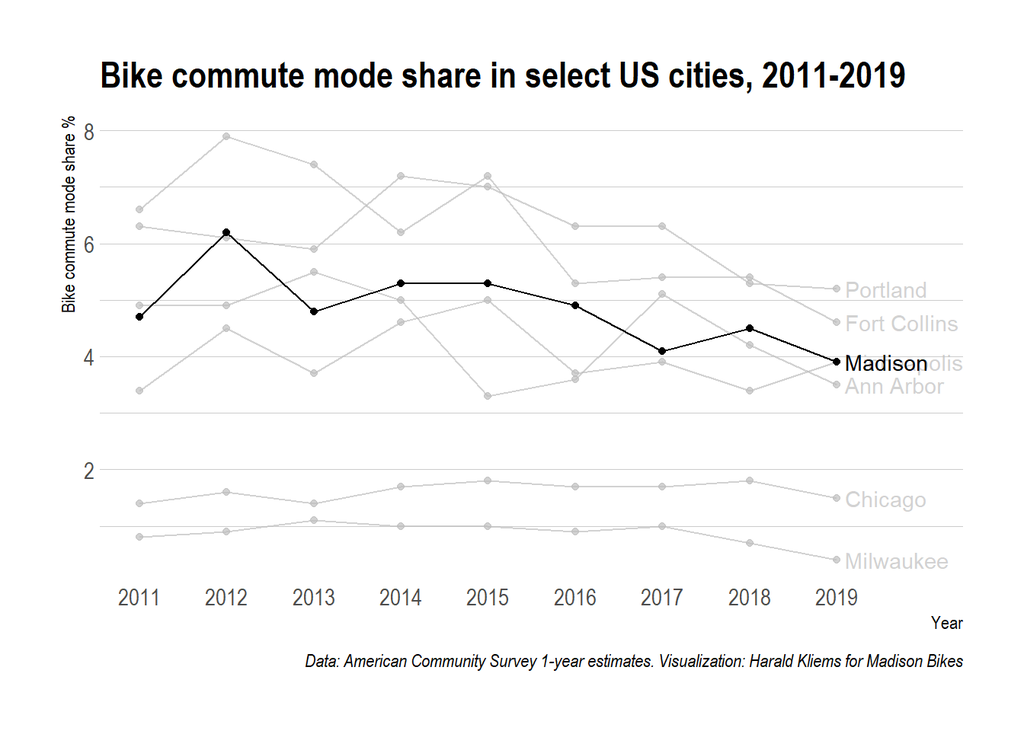

It looks like Madison isn’t that unique: Other cities, many of which have a high-for-the-US bike commute mode share, also have flat or slightly downward trends.

With bike commuting stagnating, how are other modes of transportation doing? Let’s compare the other modes of commuting in Madison.

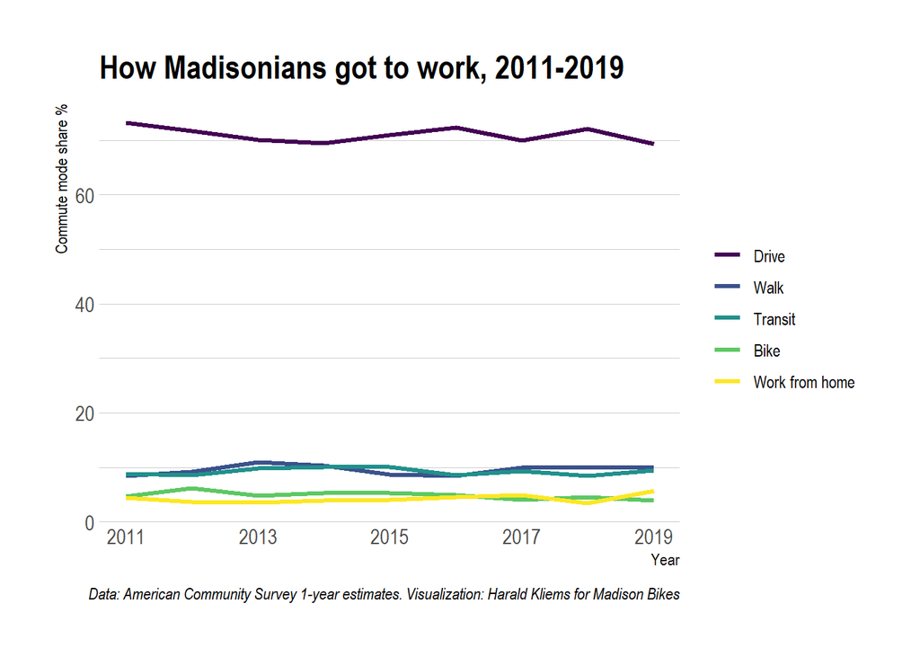

So far, so bad. One thing we need to keep in mind: The *proportion* of people commuting to work by car, bus, bike, etc. is one thing. But Madison is a growing city, and for things like congestion or CO<sub>2</sub> emissions, we have to look at *absolute* numbers:

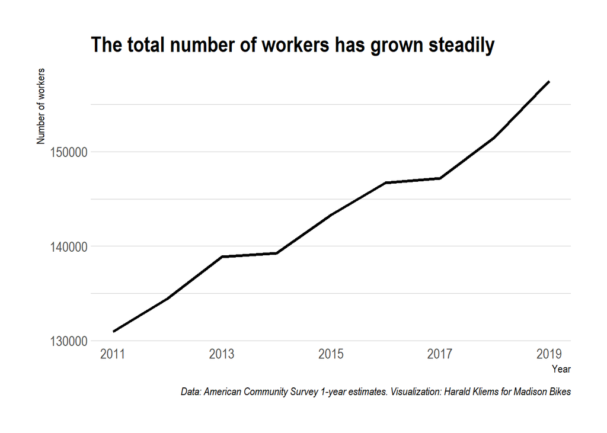

Compared to 2011, there are 26575 more working Madisonians in 2019. So if, say, the car commute share stayed the same over that period, there’d be *more* cars on the road. We can look at these absolute numbers:

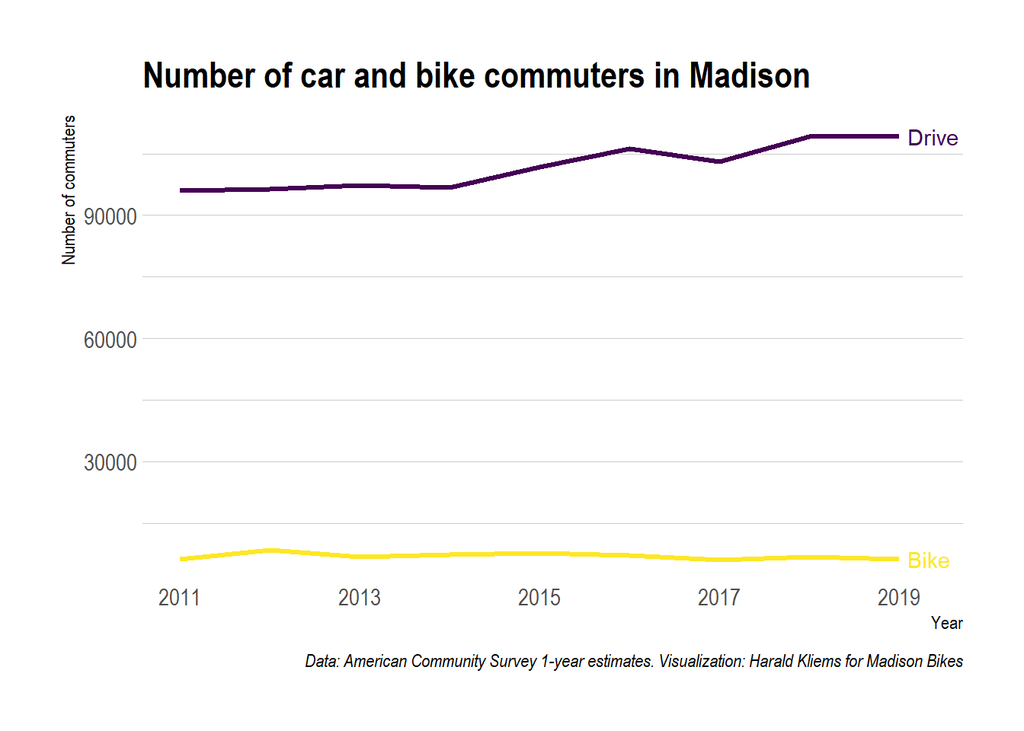

Trips to work account for [less than 20%](https://nhts.ornl.gov/assets/2017_nhts_summary_travel_trends.pdf) of all trips. So is it possible that overall biking is still growing in Madison? Maybe people drive to work, but bike more to the grocery store or for recreation? We do have one source that can help answer this question: The Eco-Counters on the Southwest Path and the Capital City Trail. [Their](https://data-cityofmadison.opendata.arcgis.com/datasets/eco-totem-capital-city-trail-bike-counts) [data](https://data-cityofmadison.opendata.arcgis.com/datasets/eco-totem-southwest-path-bike-counts) don’t reach back all the way to 2011, but we do have several year’s worth of counts:

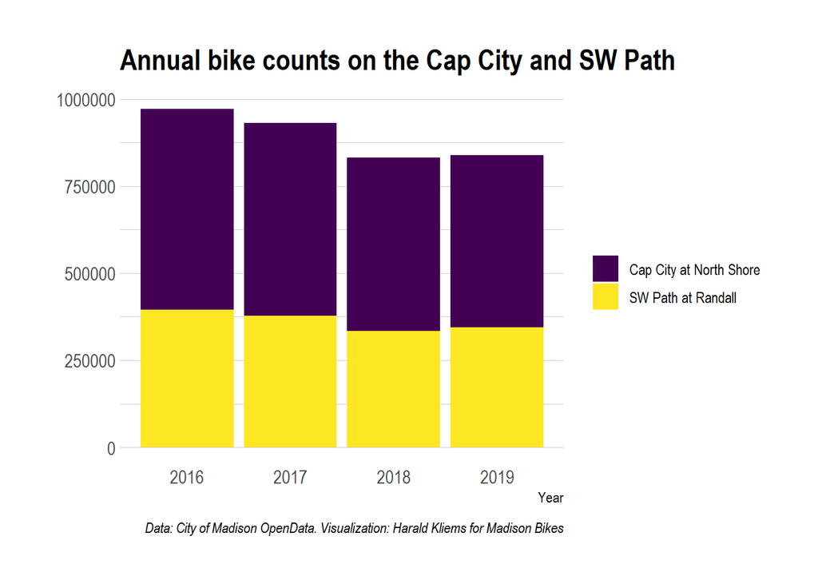

This seems to confirm: Not only is the number of people commuting to work by bike stagnating; the overall number of bike trips (at least at these two locations) has gone down as well.

What to make of all this? Madison has a reputation for being bike friendly. The League of American Bicyclists has designate us a Platinum Bike-Friendly Community, and in the latest [Places for Bikes City Rating](https://cityratings.peopleforbikes.org/city/madison/) we came in second. New bike infrastructure keeps being built. Our mayor joined a ride celebrating Madison Bike Week last year. The head of Madison’s Department of Transportation and the City Traffic Engineer are bike commuters. And still: All this doesn’t translate into a shift away from cars and toward biking.

National trends like low gas prices certainly play a role. But probably as important is the fact that locally we have still have policies and procedures in place that making driving the easy, cheap, and convenient choice. Each bike infrastructure improvement is outmatched by yet another parking garage, another lane on the Beltline, a new subdivision or corporate campus at the edge of town, or a signal retiming to keep cars moving.

It will take sustained collective action, day after day, year after year, to move the needle. Madison Bikes is one piece of that collective action, but we can’t do it without you. Write to your Alder, provide testimony at public meetings, organize your neighborhood, [join our board of directors](https://www.madisonbikes.org/2020/09/join-the-board-of-madison-bikes/), [support us financially](https://www.madisonbikes.org/donate/).

[^1]: Maybe more precisely one would have to say “use biking as their main mode of transportation to work”. The actual question in the ACS is: “How did this person usually get to work LAST WEEK? If this person used more than one method of transportation during the trip, mark (x) the box of the one used for most of the distance.” Note the qualification about “used for most of the distance.” Someone who bikes from their home on the far west side to the nearest bus stop and then takes the bus downtown? They would be counted as a bus commuter. Also note the word “usually.” Someone who rides their bike two days a week and takes the bus on the other days? Again, a public transit commuter, according to the survey.